```python
__author__ = "Yuqiao(Echo) Zhong"
__email__ = "yuqiao.zhong@simon.rochester.edu"
__website__ = "https://www.linkedin.com/in/yuqiaoechozhong/"
```

# Part 1 - Introduction

My ultimate goal for this project is to predict whether a Yelp review is 1 star or 5 star based on the text content. I took a machine learning course taught by Jose Portilla on Udemy. And now I want to apply what I learned into a new project.

First I vectorized text messages into a form that machine learning algorithms can understand. Next I train a machine learning model to learn to discriminate between 1 star and 5 star messages. Finally, with the trained model, I will classify the reviews into 1 star or 5 star.

Dataset Informatiom The yelp review dataset is obtained from Kaggle dataset (https://www.kaggle.com/c/yelp-recsys-2013Each). Each observation in this dataset is a review of a particular business by a particular user. The "stars" column is the number of stars (1 through 5) assigned by the reviewer to the business. (Higher stars is better.) In other words, it is the rating of the business by the person who wrote the review. The "cool" column is the number of "cool" votes this review received from other Yelp users. The "useful" and "funny" columns are similar to the "cool" column.

# Part 2 - Exploratory Data Analysis

**Import the libraries**

```python
import pandas as pd
import numpy as np
import seaborn as sns
import matplotlib.pyplot as plt
%matplotlib inline
```

**Load the data**

```python
yelp = pd.read_csv('yelp.csv')
yelp.head()
```

|  | business_id | date | review_id | stars | text | type | user_id | cool | useful | funny |
| --- | --- | --- | --- | --- | --- | --- | --- | --- | --- | --- |
| 0 | 9yKzy9PApeiPPOUJEtnvkg | 2011-01-26 | fWKvX83p0-ka4JS3dc6E5A | 5 | My wife took me here on my birthday for breakf... | review | rLtl8ZkDX5vH5nAx9C3q5Q | 2 | 5 | 0 |
| 1 | ZRJwVLyzEJq1VAihDhYiow | 2011-07-27 | IjZ33sJrzXqU-0X6U8NwyA | 5 | I have no idea why some people give bad review... | review | 0a2KyEL0d3Yb1V6aivbIuQ | 0 | 0 | 0 |
| 2 | 6oRAC4uyJCsJl1X0WZpVSA | 2012-06-14 | IESLBzqUCLdSzSqm0eCSxQ | 4 | love the gyro plate. Rice is so good and I als... | review | 0hT2KtfLiobPvh6cDC8JQg | 0 | 1 | 0 |
| 3 | _1QQZuf4zZOyFCvXc0o6Vg | 2010-05-27 | G-WvGaISbqqaMHlNnByodA | 5 | Rosie, Dakota, and I LOVE Chaparral Dog Park!!... | review | uZetl9T0NcROGOyFfughhg | 1 | 2 | 0 |
| 4 | 6ozycU1RpktNG2-1BroVtw | 2012-01-05 | 1uJFq2r5QfJG_6ExMRCaGw | 5 | General Manager Scott Petello is a good egg!!!... | review | vYmM4KTsC8ZfQBg-j5MWkw | 0 | 0 | 0 |

**Create a new column to record the length of each review**

```python
yelp['text length'] = yelp['text'].apply(len)
```

**First, let's see how many reviews are in each star.**

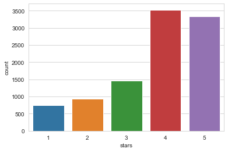

```python
sns.countplot(yelp['stars'])
```

Most reviews are in the 4 star category.

**Let's use FacetGrid to create a grid of 5 histograms of text length based off of the star ratings**

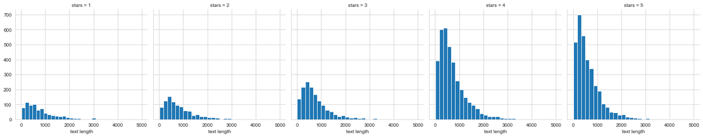

```python
sns.set_style('whitegrid')
length_hist = sns.FacetGrid(yelp, col="stars", height=4)
length_hist.map(plt.hist, "text length", bins=30)
```

From the length distribution plots, it seems like most reviews are around 500 words. There are much more reviews in the 4 and 5 stars reviews. But let's further explore if there is any outliers.

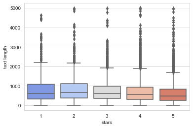

```python
sns.boxplot(x='stars',y='text length',data=yelp, palette='coolwarm')
```

Interesting finding, 5 star review actually has the least amount of text but a lot of outliers. There are about 3 of them are over 4500 words. What are they?

```python
for message in yelp[(yelp['stars']==5) & (yelp['text length']>4500)]['text']:
    print (message,"\n\n")
```

```
Pizzeria Bianco: Before and After
Cited as "the best pizza in America" in numerous on-line reviews as well as on Good Morning America and as published in, Slice of Heaven, to most pizza lovers the three to four hour wait for a table is so daunting that they push on to a more open table atmosphere for their pizza experience. But to t…
My decision to try Pizzeria Bianco for the first time came from a challenge I put upon myself: Find the best food in metropolitan Phoenix. After hearing about Pizzeria Bianco from a friend, I made gourmet pizza my first battle in 2009. I knew about the long lines forming an hour or more before the r…
When we were seated at 6:00, the four of us started with the homemade mozzarella, local tomato and sweet basil starter with extra virgin olive oil drizzled all over as well as homemade crusty bread with a dish of EVOO with a touch of balsamic added. We ordered three pizzas, the Sonny Boy providing s…
And so, after hearing of the departure of Chris from the kitchen, curiosity got the best of me. I had to challenge this place and find out if the changing of the guard made any difference in the wait time, the food quality or the overall experience I had truly fallen for. April 6, 2010 again I ventu…
Bob trotted off to Bar Bianco to find our pale ale, Four Peaks to help pass the time. We caught a glimpse of owner Chris Bianco and I told Bob how I would love to chat with him seeing as I was writing a comparison review, I also wanted to find out who was cooking tonight. Bob stalked Chris into Bar …
At 6:15pm, after 2.25 hours of complete social enjoyment we were called to our seats at the bar. We ordered the same items we had enjoyed last fall with the exception of the Marinara. The overall experience was better for me as I got to enjoy personal time with Chris. As for the meal, it was just as…
So what makes for the "best pizza in America" and how did Pizzeria Bianco get the tag line? Well, my opinion is flavorful ingredients, a phenomenal social experience, and an owner who lives by what he serves. To Chris Bianco and the Pizzeria Bianco staff, you haven't skipped a beat!


Owned and operated by Eugenia Theodosopoulos (an Ohio native, fyi) and considered by many to be the best patisserie/bakery in the state I approached Essence with a note of skepticism largely assuming much of the hype was derived from Tempe's plethoric college crowd but arriving at the doors of the s…

Now bearing in mind that the original impetus to visit Tempe on this particular morning was to visit Caffe Boa and that Essence was more of 'pre-meal' activity what follows may seem slightly gluttonous, but to be fair once I took my first bite of Theodosopoulos's École Lenôtre trained almond croissa…

Moving next from the baked goods to one prepared from the menu my second taste of the morning aside from the slightly earthy and lightly leather accented coffee was Essence's "Signature" French Toast, a $7.25 selection featuring three griddled slices of eggy brioche and a sidecar of what I can best …

At this point submitting to the fact that I was going to eat even the items I'd bought 'for later,' my next two tastes were a pair of $2.95 macarons that, much like the croissant, rivaled those both here and abroad in terms of taste and texture while opting for a much more rustic approach terms of s…

If there were any 'misstep' on the morning, it *might* have been the "Summer Berry Croissant Bread Pudding," though when I say misstep I must temper the comment with the fact that my quibble is only that I prefer the French/English take on the dish while this one was more based on the French Custard…

Moving last to the one dish that gave me trepidation, the "French Napoleon" gave caused pause not only because the name clearly skewed towards a subset unfamiliar with a proper Mille-Feuille but also because so many pre-made versions of this layered pastry have failed to wow in the past...thankfully…


Wow. Wow Freakin' Wow.

I have never, ever had such a perfect dining experience from the minute they greet you, learn your name, cater to your every need, and give you FABULOUS, beautifully prepared food since...well, NEVER.

I must say I did do my research, so I did know what I wanted to try and even though I kind of expected the JW Marriott to be more of a snooty place, I felt it would be closest to my house and wanted to find out for myself what all the hoopla was about this Roy person and his fish.

I went with my friend Amy who was visiting from New York. She had been to Roy's before and is a fellow foodie. We got to the restaurant early and went outside on the immense patio area to sit and have a drink. It's December so a bit chilly but the HUGE, soft patio furniture was extremely cozy and we…

When we meandered inside for dinner, the hostess greeted us by name and our server showed us to our table. She was very competent, could make recommendations, and was pleasant without being clingy. We loved her. She reminded me of Joan Cusack. Sounded just like her!

The complimentary appetizer of lightly spiced, steamed edamame was delightful and even though they gave us warmed wet washcloths we were complete heathens and ate with our hands without ever using them.
```

[output cut: 18 more lines]

**Interesting value-added insights, now let's take a look at a mean value for all the columns for each star and see if we can find any correlation.**

```python
stars_stats = yelp.groupby('stars').mean()
stars_stats
```

| stars | cool | useful | funny | text length |
| --- | --- | --- | --- | --- |
| 1 | 0.576769 | 1.604806 | 1.056075 | 826.515354 |
| 2 | 0.719525 | 1.563107 | 0.875944 | 842.256742 |
| 3 | 0.788501 | 1.306639 | 0.694730 | 758.498289 |
| 4 | 0.954623 | 1.395916 | 0.670448 | 712.923142 |
| 5 | 0.944261 | 1.381780 | 0.608631 | 624.999101 |

Higher reviews tend to have shorter text length and lower funny attributes. This makes sense because usually the good reviews just describe how good the restaurant is and tend not to be humorous. Vice versa, lower reviews tend to have longer text length and higher useful attributes.

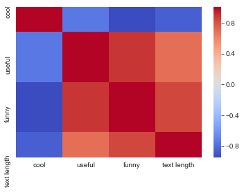

```python
sns.heatmap(stars_stats.corr(),cmap='coolwarm')
```

A cool message tends to be not so funny; and a funny review tends to be more useful. These are all just correlations.

**From the EDA process, we can conclude the dataset contains a higher portion of 4 and 5 star reviews. As of length, all the reviews tend to have text length at around 600-800. Higher review have shorter length and lower funny attributes, while bad reviews tend to have longer lenth and higher useful attribute and lower cool attribute.**

# Part 3 - NLP Classification Task

**First, let's clean the data and remove the punctuation and stop words in the text.**

```python
import string
import nltk
from nltk.corpus import stopwords
nltk.download('stopwords')
```

```
True
```

```python
def text_process(mess):
    """
    Takes in a string of text, then performs the following:
    1. Remove all punctuation
    2. Remove all stopwords
    3. Returns a list of the cleaned text
    """
    # Check characters to see if they are in punctuation
    nopunc = [char for char in mess if char not in string.punctuation]

    # Join the characters again to form the string.
    nopunc = ''.join(nopunc)

    # Now just remove any stopwords
    return [word for word in nopunc.split() if word.lower() not in stopwords.words('english')]
```

```python
yelp['text'].apply(text_process)
```

```
0       [wife, took, birthday, breakfast, excellent, w...
1       [idea, people, give, bad, reviews, place, goes...
2       [love, gyro, plate, Rice, good, also, dig, can...
3       [Rosie, Dakota, LOVE, Chaparral, Dog, Park, co...
4       [General, Manager, Scott, Petello, good, egg, ...
                              ...
9995    [First, visitHad, lunch, today, used, Groupon,...
9996    [called, house, deliciousness, could, go, item...
9997    [recently, visited, Olive, Ivy, business, last...
9998    [nephew, moved, Scottsdale, recently, bunch, f...
9999    [45, locations, 45, star, average, think, Ariz...
Name: text, Length: 10000, dtype: object
```

**Now we have the text data ready to be analyzed, let's split the data into training and test dataset.**

**First, let's only look at 1-star and 5-star data.**

```python
yelp_class=yelp[(yelp.stars==1) | (yelp.stars==5)]
```

```python
from sklearn.model_selection import train_test_split
X=yelp_class['text']
y=yelp_class['stars']
X_train,X_test,y_train,y_test = train_test_split(X,y,test_size=0.3,random_state=101)
```

**Next, let's create a pipeline to train the model. The pipeline will consist of three parts:**

**1) Vectorize the processed text message to integer counts**

**2) Weight the counts to TF-IDF scores**

**3) Train the model with Naive Bayes classifier.**

```python
from sklearn.feature_extraction.text import CountVectorizer # vectorize the text
from sklearn.feature_extraction.text import TfidfTransformer # weight the counts
from sklearn.naive_bayes import MultinomialNB # Use naive bayes model to train and predict the data
```

```python
from sklearn.pipeline import Pipeline
pipeline = Pipeline([
    ('bow', CountVectorizer(analyzer=text_process)),  # strings to token integer counts
    ('tfidf', TfidfTransformer()),  # integer counts to weighted TF-IDF scores
    ('classifier', MultinomialNB()),  # train on TF-IDF vectors w/ Naive Bayes classifier
])
```

**Ok, let's train and fit the data!**

```python
pipeline.fit(X_train,y_train)
prediction = pipeline.predict(X_test)
```

# Evaluate the model

```python
from sklearn.metrics import confusion_matrix, classification_report
print(confusion_matrix(y_test,prediction))
print('\n\n')
print(classification_report(y_test,prediction))
```

```
[[  0 228]
 [  0 998]]



              precision    recall  f1-score   support

           1       0.00      0.00      0.00       228
           5       0.81      1.00      0.90       998

    accuracy                           0.81      1226
   macro avg       0.41      0.50      0.45      1226
weighted avg       0.66      0.81      0.73      1226
```

The results are not very good. Let's try not including the Tfidf method.

```python
from sklearn.pipeline import Pipeline
pipeline2 = Pipeline([
    ('bow', CountVectorizer(analyzer=text_process)),  # strings to token integer counts
    ('classifier', MultinomialNB()),  # train on TF-IDF vectors w/ Naive Bayes classifier
])
```

```python
pipeline2.fit(X_train,y_train)
prediction = pipeline2.predict(X_test)
```

```python
print(confusion_matrix(y_test,prediction))
print('\n\n')
print(classification_report(y_test,prediction))
```

```
[[143  85]
 [ 11 987]]



              precision    recall  f1-score   support

           1       0.93      0.63      0.75       228
           5       0.92      0.99      0.95       998

    accuracy                           0.92      1226
   macro avg       0.92      0.81      0.85      1226
weighted avg       0.92      0.92      0.92      1226
```

# Part 4 - Conclusion

Overall accuracy reaches 92%. 96 out of 1226 reviews are put in the wrong category.

Before using machine learning techniques to identify reviews, I cleaned the dataset of 10000 messages obtained from Kaggle Yelp review dataset by removing punctuation and stop words in each review. Then I choose the data which only contains 1 star and 5 star reviews to further train the data. I created a pipeline that vectorized the text messages, calculated TF-IDF of each vector, and train the data with Naive Bayes algorithm. However the model only reached accuracy rate of 81% overall.

I then remove the TF-IDF step from the whole process and re-calculate the accuracy and it turns out to be much higher to 92%.

This is just a very simple project to apply what I have learned of Natural Language Processing to a Kaggle dataset, but there are many other techniques that can enhance the process.